# Bayesian two-stage designs for two-arm phase II trials with binary endpoints

In summary, `res_rio$design` tells us how many patients are recruited in each arm at the interim and at the final analysis, and `res_rio$occ` reports the corresponding operating characteristics of this optimal two-stage design.

We can also plot the resulting design’s operating characteristics:

[figure not shown]

```r
plot_twostage_2arm_bf(res_rio)
```

The plot also visualizes our expectations about the effect of the drug. The design priors indicate that smaller response probabilities close to zero are much more likely a priori in the control group than in the treatment group, whereas larger response probabilities are more likely in the treatment group (compare the dashed and solid lines in the bottom panel for the design prior under $H_+$, $p_1$ was the success probability in the control arm and $p_2$ the success probability in the treatment arm). This expectation about the effectiveness of the new treatment is independent of the analysis priors used when computing the Bayes factor $BF_{+0}$, which are flat and in that sense objective (compare the dashed and solid lines in the analysis prior panels, which overlap; therefore, under $H_+$ it looks as if only a single line is in the plot): subjectivity only enters the planning stage of the trial, not the interim or final analysis itself.

### 6.4 Comparison with the fixed-sample design

The following table summarizes the key Bayesian operating characteristics of the fixed-sample one-stage design at $N_{\text{total}} = 51$ and of the optimal two-stage design with interim look at $(n_1^{(1)}, n_1^{(2)}) = (13, 13)$ and maximum total sample size $N_{\text{total}} = 68$.

Bayesian operating characteristics of the fixed-sample one-stage design at \(N_{\text{total}} = 51\) and the corresponding optimal two-stage design with interim look at \((n_1^{(1)}, n_1^{(2)}) = (13, 13)\) and maximum total sample size \(N_{\text{total}} = 68\) for the riociguat example.

[output not shown]

### 6.5 Interpretation of the small futility probability

In the riociguat example, the optimal two-stage design only stops early for futility under $H_0$ with probability about $0.02$, so the reduction in the expected sample size under $H_0$ is very modest. This behaviour is not a bug of the algorithm, but a consequence of the modelling choices and calibration constraints.

First, the design is calibrated to fairly strict evidence requirements: the success threshold $k = 1/10$, the null-evidence threshold $k_f = 3$, the Bayesian type-I error bound $\alpha = 0.025$, and the requirement $\Pr(\mathrm{CE}\mid H_0) \ge 0.60$ together imply that only a small fraction of $H_0$ outcomes can be eliminated safely at the interim look without compromising either power or the probability of compelling evidence in favour of $H_0$. Under such constraints, the interim boundary cannot be very aggressive, so the early stopping probability under $H_0$ remains low and $E_{H_0}(N)$ stays close to the maximum sample size.

Third, the design priors have a pronounced effect on the expected sample size under $H_0$. When the design priors under $H_1^+$ are made more informative and more clearly separated from $H_0$, the predictive distributions under $H_0$ and $H_1^+$ diverge more quickly as the sample size grows. This leads to a smaller sufficient fixed-sample size and, consequently, to a smaller expected sample size under $H_0$ in the corresponding two-stage design, even if the interim futility probability itself changes only marginally. In the riociguat example, this can be achieved by concentrating the design priors slightly more around the clinically relevant success rates, while keeping the analysis priors and Bayes factor thresholds unchanged.

To illustrate this effect, consider a modified design where the analysis priors are left as in the original example, but the design priors under $H_1^+$ are made more informative, with $\mathrm{Beta}(1, 5)$ for the control arm and $\mathrm{Beta}(5, 1)$ for the experimental arm. Using the call

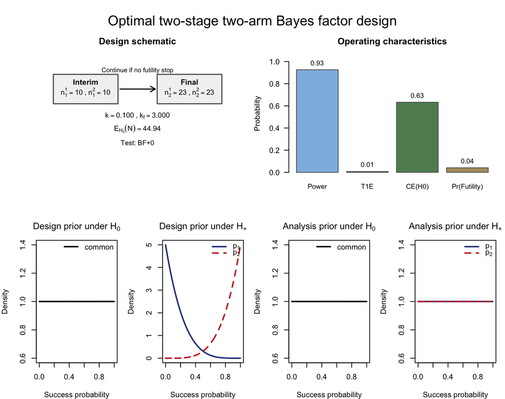

Figure 4: The calibrated Bayesian two-arm two-stage phase II design with binary endpoints, now using slightly more informative Beta design priors. An interim analysis is carried out at sample sizes of 10 patients per trial arm, and the design is calibrated according to the target constraints of 80% Bayesian power, 2.5% Bayesian type-I-error and 60% probability of compelling evidence for the null hypothesis. THe final analysis is carried out after 23 patients have been recruited per trial arm. Note that the expected sample size under the null hypothesis has substantially decreased compared to the earlier optimal design under less informative design priors.

```r
res_rio_more_informative_design_priors <- optimal_twostage_2arm_bf(
  alpha = 0.025,
  beta = 0.20,
  k = 1/10,
  k_f = 3,
  n1_min = c(10, 10),
  n2_max = c(80, 80),
  alloc1 = 0.5,
  alloc2 = 0.5,
  power_cushion = 0.03,
  pceH0 = 0.60,
  interim_fraction = c(0.25, 0.9),
  grid_step = 1,
  progress = TRUE,
  max_iter = 500L,
  compute_freq_oc = FALSE,
  test = "BF+0",
  a_0_d = a_0_d_rio, b_0_d = b_0_d_rio,
  a_0_a = a_0_a_rio, b_0_a = b_0_a_rio,
  a_1_d = 1, b_1_d = 5,
  a_2_d = 5, b_2_d = 1,
  a_1_a = a_1_a_rio, b_1_a = b_1_a_rio,
  a_2_a = a_2_a_rio, b_2_a = b_2_a_rio
)

plot_twostage_2arm_bf(res_rio_more_informative_design_priors)
```

with corrected Bayesian operating characteristics

### 6.6 Interpretation of the `conv` flag

The component `conv` in the output of `optimal_twostage_2arm_bf()` summarizes how the calibration algorithm terminated.

- `"converged"`  
  A fully feasible design was found: step 1 identified a fixed-sample design that meets the Bayesian constraints, and step 2 found at least one two-stage design on the interim grid whose corrected operating characteristics satisfy the specified targets. The returned design is the one that minimizes the expected sample size under $H_0$ among all such candidates.
- `"no_feasible_fixed"`  
  Step 1 could not find any fixed-sample design (within the range implied by `n1_min`, `n2_max`, `max_iter`, and the thresholds) that satisfies the Bayesian constraints. In this case step 2 is not entered at all, because there is no “sufficient” one-stage design to base a two-stage search on. Typical remedies are to relax the constraints (e.g. increase `alpha`, relax `pceH0`, or reduce `1 - beta`) or to increase `n2_max` and `max_iter`.
- `"no_interim_grid"`  
  A fixed-sample design was found in step 1, but the admissible interim-sample region implied by `n1_min`, `n2_max`, and `interim_fraction` is empty. In other words, there is no pair $(n_1^{(1)}, n_1^{(2)})$ that both lies strictly below $(n_2^{(1)}, n_2^{(2)})$ and satisfies the interim-range constraints. In this case the algorithm cannot construct any two-stage candidates. Adjusting `n1_min` or widening `interim_fraction` usually resolves this.
- `"no_feasible_design"`  
  Both step 1 and step 2 ran, and at least one interim grid was evaluated, but no two-stage design on that grid satisfies the specified constraints on power, type-I error, and (optionally) `pceH0`. The function returns `NA` for the design and corrected operating characteristics in this case. To obtain a feasible design, one can enlarge the search space (e.g. increase `n2_max` or allow a finer grid via `grid_step`) or relax the Bayesian constraints.

### 6.7 How priors and thresholds affect the calibration grid (and runtime)

#### 6.7.1 Design priors and required sample size

The design priors under $H_0$ and $H_1$ determine how quickly the Bayes factor accumulates evidence as $n$ increases.

- **Flat design priors (e.g.** $\mathrm{Beta}(1,1)$ everywhere) spread substantial prior mass over a wide range of response rates. Under such diffuse priors, the Bayes factor tends to move more slowly away from 1, and the algorithm typically needs a **larger fixed-sample size** in step 1 to achieve the desired power and type-I error under the design priors. We strongly discourage using flat priors solely for the sake of staying objective, in particular, because the design priors do not influence the results of the Bayes factor. This is the job of the analysis prior in the planning of a trial and here, we encourage using uninformative or flat analysis priors.
- **More informative design priors** that concentrate mass near clinically plausible values can lead to **smaller sufficient fixed-sample sizes**, because the predictive distributions under $H_0$ and $H_1$ separate more quickly.

Because a larger fixed-sample size directly expands the admissible range for $(n_1^1, n_1^2)$, using very flat design priors can lead to a **very large interim design grid** in step 2 and thus considerably longer runtimes.

A simple (non-evaluated) example illustrating the “flat vs informative” effect is:

```r
# NOT RUN
# Very flat design priors (tend to require larger n2)
res_flat <- optimal_twostage_2arm_bf(
  alpha = 0.025, beta = 0.20, pceH0 = 0.60,
  k = 1/10, k_f = 3,
  n1_min = c(5, 5), n2_max = c(200, 200),
  alloc1 = 0.5, alloc2 = 0.5,
  interim_fraction = c(0, 1),
  grid_step = 1,
  power_cushion = 0.03,
  progress = TRUE,
  max_iter = 2000,
  test = "BF+0",
  a_0_d = 1, b_0_d = 1,
  a_0_a = 1, b_0_a = 1,
  a_1_d = 1, b_1_d = 1,
  a_2_d = 1, b_2_d = 1,
  a_1_a = 1, b_1_a = 1,
  a_2_a = 1, b_2_a = 1
)

# More informative design priors (likely smaller n2, fewer interim designs)
# res_inf <- optimal_twostage_2arm_bf(
#   alpha = 0.025, beta = 0.20, pceH0 = 0.60,
#   k = 1/10, k_f = 3,
#   n1_min = c(5, 5), n2_max = c(200, 200),
#   alloc1 = 0.5, alloc2 = 0.5,
#   interim_fraction = c(0, 1),
#   grid_step = 1,
#   power_cushion = 0.03,
#   progress = TRUE,
#   max_iter = 2000,
#   test = "BF+0",
#   a_0_d = a_0_d_rio, b_0_d = b_0_d_rio,
#   a_0_a = a_0_a_rio, b_0_a = b_0_a_rio,
#   a_1_d = a_1_d_rio, b_1_d = b_1_d_rio,
#   a_2_d = a_2_d_rio, b_2_d = b_2_d_rio,
#   a_1_a = a_1_a_rio, b_1_a = b_1_a_rio,
#   a_2_a = a_2_a_rio, b_2_a = b_2_a_rio
# )
```

In practice, one can expect `res_flat` to require a larger fixed-sample size in step 1, and hence to explore more interim designs in step 2, than a corresponding design based on more concentrated priors.

#### 6.7.2 Evidence threshold $k$ and required sample size

The **efficacy threshold** $k$ determines how strong the evidence against $H_0$ must be before declaring success. For BF+0, success corresponds to the event “Bayes factor in favour of $H_+$ vs $H_0$ drops below $k$”.

- If $k$ is very small (e.g. $k = 1/10$), then very strong evidence is required to reject $H_0$. This typically forces the algorithm to choose **larger fixed-sample sizes** to reach the desired power.
- If $k$ is less extreme (e.g. $k = 1/3$), the evidence threshold is easier to reach, so **smaller fixed-sample sizes** can be sufficient.

Since the fixed-sample size from step 1 determines the upper bound for the interim sample sizes, choosing a **larger** (less stringent) $k$ tends to **reduce** the number of interim designs and the runtime of the calibration procedure; choosing a **smaller** $k$ has the opposite effect.

A simple illustration (not evaluated in the vignette) is:

```r
# NOT RUN
# More stringent evidence threshold (k = 1/10)
res_strict <- optimal_twostage_2arm_bf(
  alpha = 0.025, beta = 0.20, pceH0 = 0.60,
  k = 1/10, k_f = 3,
  n1_min = c(5, 5), n2_max = c(150, 150),
  alloc1 = 0.5, alloc2 = 0.5,
  interim_fraction = c(0, 1),
  grid_step = 1,
  power_cushion = 0.03,
  progress = TRUE,
  max_iter = 2000,
  test = "BF+0",
  a_0_d = a_0_d_rio, b_0_d = b_0_d_rio,
  a_0_a = a_0_a_rio, b_0_a = b_0_a_rio,
  a_1_d = a_1_d_rio, b_1_d = b_1_d_rio,
  a_2_d = a_2_d_rio, b_2_d = b_2_d_rio,
  a_1_a = a_1_a_rio, b_1_a = b_1_a_rio,
  a_2_a = a_2_a_rio, b_2_a = b_2_a_rio
)

# Less stringent evidence threshold (k = 1/3)
# res_looser <- optimal_twostage_2arm_bf(
#   alpha = 0.025, beta = 0.20, pceH0 = 0.60,
#   k = 1/3, k_f = 3,
#   n1_min = c(5, 5), n2_max = c(150, 150),
#   alloc1 = 0.5, alloc2 = 0.5,
#   interim_fraction = c(0, 1),
#   grid_step = 1,
#   power_cushion = 0.03,
#   progress = TRUE,
#   max_iter = 2000,
#   test = "BF+0",
#   a_0_d = a_0_d_rio, b_0_d = b_0_d_rio,
#   a_0_a = a_0_a_rio, b_0_a = b_0_a_rio,
#   a_1_d = a_1_d_rio, b_1_d = b_1_d_rio,
#   a_2_d = a_2_d_rio, b_2_d = b_2_d_rio,
#   a_1_a = a_1_a_rio, b_1_a = b_1_a_rio,
#   a_2_a = a_2_a_rio, b_2_a = b_2_a_rio
# )
```

Here, one would expect `res_strict` to require a larger fixed-sample size and thus more interim designs than `res_looser`.

#### 6.7.3 Probability of compelling evidence for $H_0$ and feasibility

The optional constraint on $\Pr(\mathrm{CE}\mid H_0)$ (specified via `pceH0`) is evaluated under $H_0$ and requires a sufficiently **large sample size** for the Bayes factor to accumulate strong evidence *in favour* of $H_0$. For small total sample sizes:

- It may be impossible to reach the desired `pceH0` (even with favourable data), because the Bayes factor cannot move far enough towards $H_0$ when $n$ is small.
- In such cases, the fixed-sample search in step 1 will typically continue to larger $n$ in an attempt to meet the `pceH0` constraint. If `n2_max` is restrictive, it may ultimately **fail** to find a design that satisfies all constraints.

This leads to an important tension:

- **Smaller sufficient fixed-sample sizes** (e.g. from a less stringent $k$) make the step-2 search faster but can make it **hard (or impossible)** to reach a demanding `pceH0` (such as 0.8 or 0.9), because there simply is not enough information in the data to strongly favour $H_0$.
- **Larger fixed-sample sizes** (e.g. from stricter priors or smaller $k$) make satisfying `pceH0` more feasible but increase the number of interim designs and thus the runtime.

A minimal illustration that emphasises feasibility (not evaluated) could look like:

```r
# NOT RUN
# Modest P(CE|H0) target
res_ce60 <- optimal_twostage_2arm_bf(
  alpha = 0.025, beta = 0.20, pceH0 = 0.60,
  k = 1/10, k_f = 3,
  n1_min = c(5, 5), n2_max = c(120, 120),
  alloc1 = 0.5, alloc2 = 0.5,
  interim_fraction = c(0, 1),
  grid_step = 1,
  power_cushion = 0.03,
  progress = TRUE,
  max_iter = 2000,
  test = "BF+0",
  a_0_d = a_0_d_rio, b_0_d = b_0_d_rio,
  a_0_a = a_0_a_rio, b_0_a = b_0_a_rio,
  a_1_d = a_1_d_rio, b_1_d = b_1_d_rio,
  a_2_d = a_2_d_rio, b_2_d = b_2_d_rio,
  a_1_a = a_1_a_rio, b_1_a = b_1_a_rio,
  a_2_a = a_2_a_rio, b_2_a = b_2_a_rio
)

# More demanding P(CE|H0) target (may require larger n2 or even be infeasible)
# res_ce80 <- optimal_twostage_2arm_bf(
#   alpha = 0.025, beta = 0.20, pceH0 = 0.80,
#   k = 1/10, k_f = 3,
#   n1_min = c(5, 5), n2_max = c(120, 120),
#   alloc1 = 0.5, alloc2 = 0.5,
#   interim_fraction = c(0, 1),
#   grid_step = 1,
#   power_cushion = 0.03,
#   progress = TRUE,
#   max_iter = 2000,
#   test = "BF+0",
#   a_0_d = a_0_d_rio, b_0_d = b_0_d_rio,
#   a_0_a = a_0_a_rio, b_0_a = b_0_a_rio,
#   a_1_d = a_1_d_rio, b_1_d = b_1_d_rio,
#   a_2_d = a_2_d_rio, b_2_d = b_2_d_rio,
#   a_1_a = a_1_a_rio, b_1_a = b_1_a_rio,
#   a_2_a = a_2_a_rio, b_2_a = b_2_a_rio
# )
```

The second call with `pceH0 = 0.80` may either force `n2` to become quite large or, if `n2_max` is too restrictive, result in `conv = "no_feasible_fixed"`.

#### 6.7.4 Practical recommendation for vignettes and examples

When using the `optimal_twostage_2arm_bf()` function for designing two-stage two-arm binomial phase II trials based on Bayes factors, it is useful to:

- Choose **moderately informative design priors** rather than completely flat ones.
- Avoid extremely stringent evidence thresholds and `pceH0` targets for demonstration code.
- Use relatively modest `n2_max` and, if needed, a coarser `grid_step` (e.g. 2 or 3) to keep the number of interim designs manageable.

This keeps runtime under control.

## 7 Summary

This vignette demonstrated how to

- specify design and analysis priors for two-arm binomial Bayes factor designs,
- reproduce fixed-sample operating characteristics for given trial settings, and
- construct optimal two-stage designs that reduce the expected sample size under $H_0$ while maintaining power and controlling Bayes-factor-based type I error,
- interpret the output of the two-stage optimal design algorithm, in particular, the convergence flag,
- balance computational runtime and the choice of evidence thresholds $k$ and $k_f$ for efficacy and futility, the choice of design priors, and the probability of compelling evidence target constraints

By adjusting the prior parameters, Bayes factor thresholds, and sample size constraints, `bfbin2arm` can be tailored to a wide range of two-arm phase II trial settings. Additional vignettes on frequentist and hybrid calibration will be added in future releases of the package, once these features are implemented.

## References

European Medicines Agency. 2025. “ICH E20 Adaptive Designs for Clinical Trials - Scientific Guideline European Medicines Agency (EMA).” European Medicines Agency.

Kelter, Riko. 2026. “Power and Sample Size Calculations for Bayes Factors in Two-Arm Clinical Phase II Trials with Binary Endpoints.” https://arxiv.org/abs/2603.01715.

Kelter, Riko, and Samuel Pawel. 2025. “The Bayesian Optimal Two-Stage Design for Clinical Phase II Trials Based on Bayes Factors.” https://arxiv.org/abs/2511.23144.

Khanna, Dinesh, Yannick Allanore, Christopher P. Denton, Masataka Kuwana, Marco Matucci-Cerinic, Janet E. Pope, Tatsuya Atsumi, et al. 2020. “Riociguat in Patients with Early Diffuse Cutaneous Systemic Sclerosis (RISE-SSc): Randomised, Double-Blind, Placebo-Controlled Multicentre Trial.” *Annals of the Rheumatic Diseases* 79 (5): 618–25. https://doi.org/10.1136/annrheumdis-2019-216823.

U.S. Department of Health and Human Services Food and Drug Administration, Center for Drug Evaluation and Research (CDER), Center for Biologics Evaluation and Research (CBER). 2026. “Use of Bayesian Methodology in Clinical Trials of Drug and Biological Products - Guidance for Industry.”

U.S. Department of Health and Human Services, Food and Drug Administration, Center for Biologics Evaluation and Research, and Center for Drug Evaluation and Research. 2020. “Interacting with the FDA on Complex Innovative Trial Designs for Drugs and Biological Products - Guidance for Industry.”